# STSCI 4100: IDMb Analysis Project

# [3] DATA ANALYSIS:

## QUESTION 1:

Our first question is: **does the number of votes affect the ratings?**

In the real world, many people want to know how good a movie is before watching it. To do so, they go online to check the movie’s reviews. But here’s the thing everyone suspects:

- Films that have very few votes (i.e. unpopular films) may not have the most reliable ratings, as their reviews don’t contain much information.
- Films that have lots of votes (i.e. popular films) may suggest that the movie has larger positive reception or audience appeal.

Specifically, we’ll investigate whether or not films that have more votes tend to have higher or lower ratings (i.e. whether popularity is correlated with perceived quality).

This will provide a good opening introduction, and hopefully provide some intuition, to our analysis.

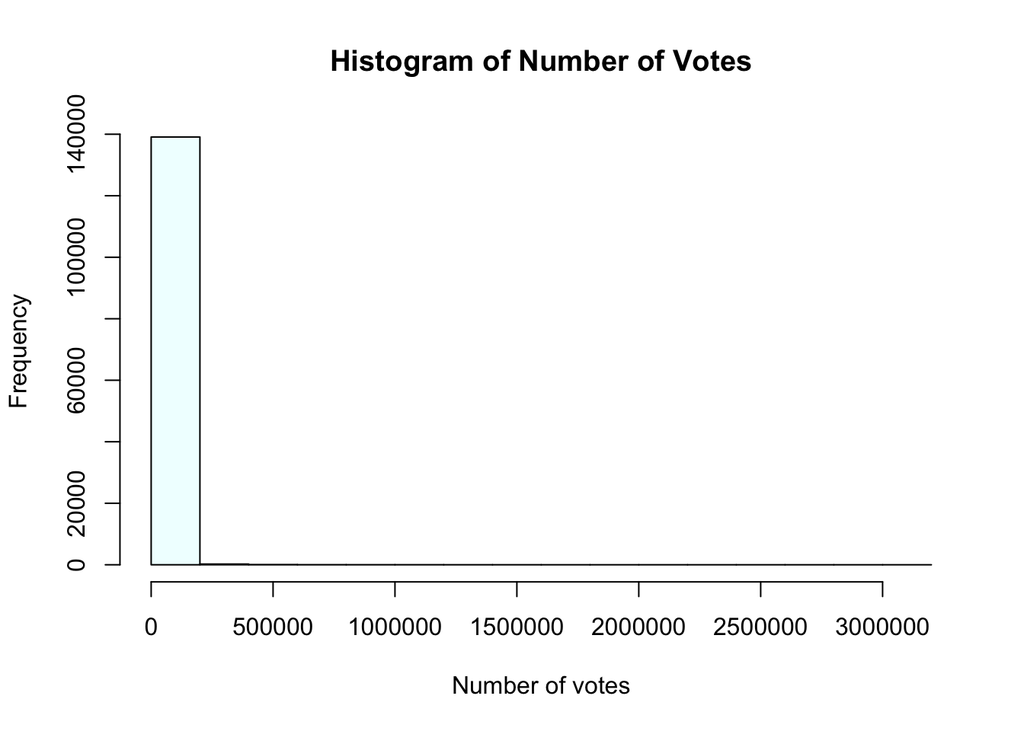

```r
# [1] First, let's visualize the distribution of the numVotes column.
hist(my.dataset$numVotes,
     xlab = "Number of votes",
     ylab = "Frequency",
     main = "Histogram of Number of Votes",
     col = "azure1")
```

```r
summary(my.dataset$numVotes)
```

```
##    Min. 1st Qu.  Median    Mean 3rd Qu.    Max.
##       5      27      88    2913     349 3021924
```

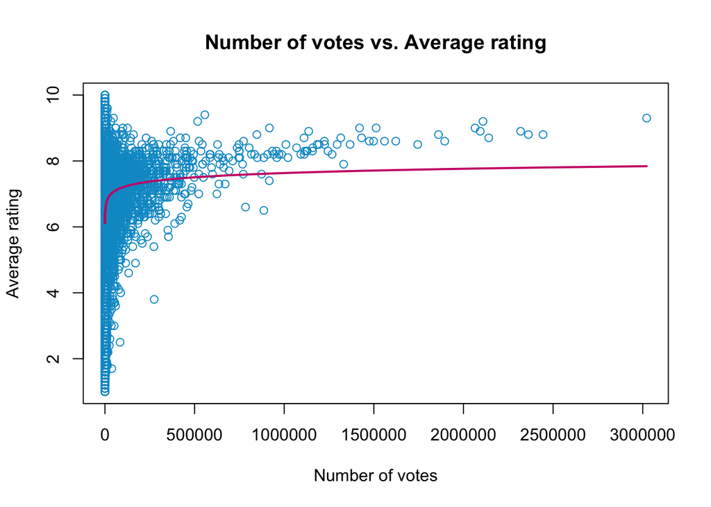

```r
# [2] Second, let's plot the numVotes column (x) against the averageRating column (y).
x <- my.dataset$numVotes
y <- my.dataset$averageRating
plot(x = x,
     y = y,
     xlab = "Number of votes",
     ylab = "Average rating",
     main = "Number of votes vs. Average rating",
     col = "deepskyblue3")

# So far, the data doesn't seem to follow a strictly linear pattern.
# The data seems to follow some sort of nonlinear pattern.
# So, let's fit a local regression model — a non-parametric statistical method — to visualize the trajectory.

# [3] Lastly, fit a local regression model.
my.lowess <- lowess(log10(x), y)                                                # Fitting a LOWESS model w/default arguments. (Computationally more efficient than LOESS.)
lines(10^my.lowess$x,                                                           # Adds LOWESS curve.
      my.lowess$y,
      col = "deeppink3",
      lwd = 2)
```

```r
# [4] Check the strength of the linear relationship between these variables.
cor(log10(x), y)
```

```
## [1] 0.1132438
```

As we can see, the number of votes in our dataset is extremely right-skewed, where:

- Most movies have very few votes. (Seems to be realistic.)
- Few movies have lots of votes. (Seems to be realistic; barely in this case.)
- Since the data is skewed, we performed a log transformation on the number of votes before fitting a local regression curve.

And here is a boxplot in support of our scatterplot with the fitted local regression:

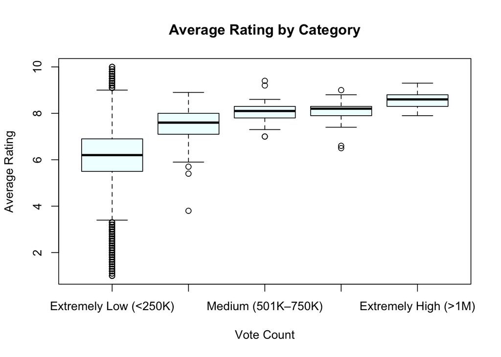

```r
my.dataset$votecategories <- NA                                                                                    # Create a new column in my.dataset.
my.dataset$votecategories[my.dataset$numVotes <= 250000] <- "Extremely Low (<250K)"                                # Category 1: Extremely Low
my.dataset$votecategories[my.dataset$numVotes > 250000 & my.dataset$numVotes <= 500000] <- "Low (251K–500K)"       # Category 2: Low
my.dataset$votecategories[my.dataset$numVotes > 500000 & my.dataset$numVotes <= 750000] <- "Medium (501K–750K)"    # Category 3: Medium
my.dataset$votecategories[my.dataset$numVotes > 750000 & my.dataset$numVotes <= 1000000] <- "High (751K-1M)"       # Category 4: High
my.dataset$votecategories[my.dataset$numVotes > 1000000] <- "Extremely High (>1M)"                                 # Category 5: Extremely High

my.dataset$votecategories <- factor(my.dataset$votecategories, levels = c("Extremely Low (<250K)",
                                                                          "Low (251K–500K)",
                                                                          "Medium (501K–750K)",
                                                                          "High (751K-1M)",
                                                                          "Extremely High (>1M)"))

boxplot(averageRating ~ votecategories,
        data = my.dataset,
        main = "Average Rating by Category",
        xlab = "Vote Count",
        ylab = "Average Rating",
        col = "azure1")
```

Here’s what we can take away from this analysis: